# Covered codend

## Summary

**This case study demonstrates:**

- Using the R package SELECCT to fit selection curves to covered-codend data.
- Fitting of logistic, Richards and semiparametric (smooth) selection curves to covered-codend data.
- Model selection and checking
- Handling sub-sampled data.
- Visualization of between-haul variability.
- Using the bootstrap to estimate uncertainty.

### Data source

The data are from a study investigation school prawn selectivity in a 30 mm square-mesh stow-net(MacBeth et al. 2005. Improving selectivity in an Australian penaeid stow-net fishery. Bulletin of Marine Science, 76: 647-660). Nineteen replicate deployments were performed.

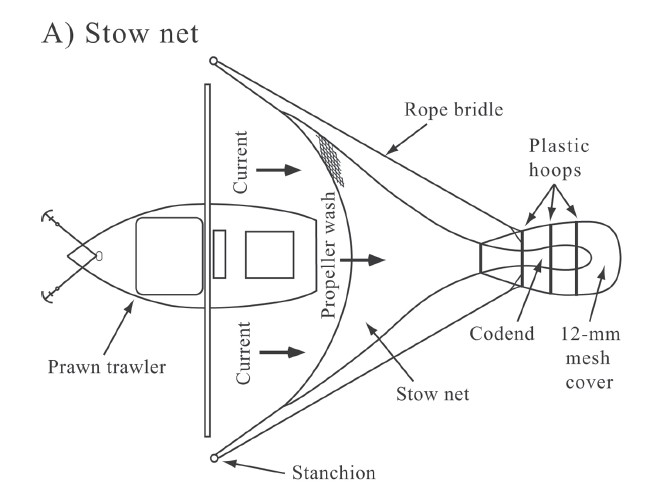

### Load required packages

```r
require(SELECT)
require(dplyr)
require(ggplot2) #For bootstrap plot
```

### Input and inspect the data

```r
#Read in data and remove zero catch lengths
Stow.df=read.csv("../Data/LgSq.csv",header=T) #343 rows
Stow.df=subset(Stow.df,total>0) #213 rows

#Quick peek at data
head(Stow.df)
```

|  | lgth | codend | cover | WtSch | qcodend | qcover | total | Haul |
| --- | --- | --- | --- | --- | --- | --- | --- | --- |
| 6 | 11 | 0 | 2 | 2.02 | 0.585 | 0.34 | 2 | 1 |
| 8 | 13 | 2 | 8 | 2.02 | 0.585 | 0.34 | 10 | 1 |
| 9 | 14 | 3 | 6 | 2.02 | 0.585 | 0.34 | 9 | 1 |
| 10 | 15 | 25 | 34 | 2.02 | 0.585 | 0.34 | 59 | 1 |
| 11 | 16 | 47 | 82 | 2.02 | 0.585 | 0.34 | 129 | 1 |
| 12 | 17 | 65 | 62 | 2.02 | 0.585 | 0.34 | 127 | 1 |

Note the presence of the sampling fractions `qcodend` and `qcover' in the data due to the catch being sub-sampled. Variable`Haul` identifies the deployment, and takes values from 1 to 19.

### Define variable names, and the names of sampling fraction variables

The names of the length and gear variables need to be specified, with the length name always given first. If there is sub-sampling then these variable names also need to be specified.

```r
v.names=c("lgth","cover","codend")
q.names=c("qcover","qcodend")
```

### Produce a plot of retention proportions

It is always a good idea to inspect the data before analysis. The code below sums the data over the nineteen deployments, and then calculates and plots the retention proportions by length.

```r
Tots=Raw2Tots(Stow.df,v.names,q.names)
Tots=transform(Tots,n=codend+cover,y=codend/(codend+cover))
Tots
```

| lgth | cover | codend | n | y |
| --- | --- | --- | --- | --- |
| 6 | 2.239274 | 0.000000 | 2.239274 | 0.0000000 |
| 8 | 1.502768 | 0.000000 | 1.502768 | 0.0000000 |
| 9 | 5.259689 | 0.000000 | 5.259689 | 0.0000000 |
| 10 | 7.513842 | 1.502768 | 9.016610 | 0.1666667 |
| 11 | 35.978043 | 4.389272 | 40.367315 | 0.1087333 |
| 12 | 42.402885 | 7.235204 | 49.638089 | 0.1457591 |
| 13 | 71.259699 | 23.271511 | 94.531210 | 0.2461781 |
| 14 | 131.173924 | 55.648326 | 186.822250 | 0.2978678 |
| 15 | 359.150971 | 235.007945 | 594.158916 | 0.3955305 |
| 16 | 729.029720 | 679.320778 | 1408.350498 | 0.4823521 |

[output cut: 7 more lines]

```r
plot(y~lgth,data=Tots,xlab="Carapace length (mm)",ylab="Propn retained")
```

[figure not shown]

The proportions look S-shaped as would normally expect. There is one possibly anomalous value at 10 mm length, but this may just be due to low numbers of this length.

### Fit a logistic selection curve, plot it, and do model checks

Standard practice is to start with the simple logistic curve and then to evaluate its fit to determine whether a more flexible curve may be preferred.

```r
Logist.fit=SELECT(Stow.df,var.names=v.names,q.names=q.names)
plot(Logist.fit, xlab="Carapace length (mm)")
```

[figure not shown]

```r
par(mfrow=c(1,2))
ModelCheck(Logist.fit, xlab="Carapace length (mm)")
```

[figure not shown]

```
## Model fit:
##     null.l    model.l     full.l       npar        AIC        BIC
## -370.68605  -38.60693  -29.77578    2.00000   81.21385   82.88028
## GOF:
##      Deviance Pearson.chisq           dof   Deviance.CF    Pearson.CF
##    17.6623038    13.8283885    15.0000000     1.1774869     0.9218926
```

```r
Estimates(Logist.fit)
```

```
##           par   raw s.e.
## L50 16.051802 0.06689251
## SR   4.746722 0.20555085
```

The logistic fit estimates `L50` and `SR` of 16.1 and 4.7 mm, respectively.

The Pearson chi-square value (13.8) is close to the degrees of freedom (15) and so the omnibus overdispersion test does not indicate lack of fit. However, the deviance residual plot does suggest some mild lack of fit due to blocks of negative and positive residuals. So, let’s try an asymmetric Richards curve fit.

### Fit a Richards selection curve

```r
Rich.fit=SELECT(Stow.df,var.names=v.names,q.names=q.names,stype="richards")
plot(Rich.fit, xlab="Carapace length (mm)")
```

[figure not shown]

```r
par(mfrow=c(1,2))
ModelCheck(Rich.fit, xlab="Carapace length (mm)")
```

[figure not shown]

```
## Model fit:
##     null.l    model.l     full.l       npar        AIC        BIC
## -370.68605  -34.03063  -29.77578    3.00000   74.06125   76.56089
## GOF:
##      Deviance Pearson.chisq           dof   Deviance.CF    Pearson.CF
##     8.5097014     5.6168274    14.0000000     0.6078358     0.4012020
```

```r
Estimates(Rich.fit)
```

```
##             par   raw s.e.
## L25   13.165287 0.31172347
## L50   16.170395 0.07621766
## L75   18.335320 0.07830442
## SR     5.170033 0.33887230
## delta  3.318629 1.19486367
```

The Richards fit eliminates the pattern in the residuals, and moreover it has considerably lower AIC than the logistic fit. Hence, the Richards is preferred. It estimates `L50` and `SR` of 16.2 and 5.2 mm, respectively. Note the asymmetry in the `L25` and `L75` values around the `L50` value.

## Between-haul variation

### Produce a lattic plot of retention proportions by haul

```r
HaulCatch=Raw2Tots(Stow.df,v.names,q.names,sumHauls=F)
HaulCatch=transform(HaulCatch,n=codend+cover,y=codend/(codend+cover))
require(lattice) #For xyplot
xyplot(y~lgth | Haul,data=HaulCatch)
```

[figure not shown]

There is some consistency between hauls, but also considerable between-haul (BHV) variation is shown. Note that haul 5 (bottom right) suggests an `L50` of about 18 mm while other hauls suggest an `L50` of around 15 mm.

### Fit a Richards selection curve to the stacked individual-haul data

Fitting to the combined individual-hauls data allows for proper quantification of between-haul variability.

```r
Rich.fit2=SELECT(Stow.df,var.names=v.names,q.names=q.names,stype="richards",
                sumHauls=F)
ModelCheck(Rich.fit2, xlab="Carapace length (mm)", minE=5, plots=F)
```

```
## Model fit:
##    null.l   model.l    full.l      npar       AIC       BIC
## -984.2317 -647.5763 -218.2059    3.0000 1301.1526 1311.2365
## GOF:
##      Deviance Pearson.chisq           dof   Deviance.CF    Pearson.CF
##    858.740853    814.138287    210.000000      4.089242      3.876849
##
## Correction factors from cells with expected count > 5 :
##      Deviance Pearson.chisq           dof   Deviance.CF    Pearson.CF
##     742.15150     714.76893      71.00000      10.45284      10.06717
```

The variance correction factor `Pearson.CF` shows that the actual variabilty could be about 10 times that assumed under the binomial model.

With this amount of variability a bootstrap should be reasonable for appropriately quantifying the variability in the estimated parameters. (The bootstrap over-estimates parameter uncertainty if BHV is slight.)

### Define function to return quantities of interest

The function defined below returns L25, L50, L75, SR, and also the predicted retention probabilities for lengths from 5 mm to 25 mm.

```r
BootStats=function(data,var.names,q.names){
  Fit=SELECT(data,var.names,q.names=q.names,stype="richards")
  Pars=Estimates(Fit)[1:4,"par"]
  Preds=predict(Fit,lens=5:25)[,3]
  c(Pars,Preds)
}
#Check that BootStats works
BootStats(Stow.df,v.names,q.names)
```

```
##         L25         L50         L75          SR
## 13.16528680 16.17039495 18.33532000  5.17003320  0.03526595  0.04484206
##
##  0.05701808  0.07249918  0.09218051  0.11719606  0.14897580  0.18930442
##
##  0.24035749  0.30464257  0.38465331  0.48180256  0.59397994  0.71196912
##
##  0.81890771  0.89900084  0.94870318  0.97543596  0.98860477  0.99479578
##
##  0.99764062
```

### Implement a bootstrap

The bootstrap can produce some warning messages, but these can be ignored as they occur from unnecessary diagnostics calculated after each bootstrap fit.

```r
nsim=100 #Use at least 1000 in practice
BootOut=bootSELECT(Stow.df,v.names,q.names,BootStats,haul="Haul",paired=T,
                    nsim=nsim,verbose=F) #Use verbose=T to see progress
```

```
## Warning in sqrt(diag(varpars)): NaNs produced
## Warning in sqrt(diag(varpars)): NaNs produced
```

```
##
## Bootstrap successfully completed
```

```r
Boot.Pars=BootOut[,1:4] #Extract L25, L50, L75 and SR
Boot.Preds=BootOut[,-(1:4)] #Extract predicted values
Predicted.Propns=predict(Rich.fit,lens=5:25)[,3]
cat("Bootstrap estimated standard errors are\n",apply(Boot.Pars,2,sd))
```

```
## Bootstrap estimated standard errors are
##  0.5587025 0.4969778 0.4706336 0.5337742
```

```r
BootPlot(Boot.Preds,5:25,Predicted.Propns,Tots)
```

```
##
##  initial.pointwise.coverage: 0.95
##  initial.simultaneous.coverage: 0.73
##  adjusted.pointwise.coverage: 1
##  adjusted.simultaneous.coverage: 0.93
```

[figure not shown]

## Semiparametric analysis

The Richards fit does estimate somewhat high retention for very small prawns, so here we explore the performance of a semiparametric fit using the `SELECT` function `SplineSELECT`.

### Fit a spline selectivity curve

```r
require(mgcv)
Spline.fit=SplineSELECT(Stow.df,var.names=v.names,q.names=q.names,
                        k=7,quasi=F)
plot(Tots$lgth,resid(Spline.fit),type="h")
abline(h=0)
```

[figure not shown]

```r
plot(y~lgth,data=Tots,xlab="Carapace length (mm)")
points(Tots$lgth,fitted(Spline.fit),type="l")
```

[figure not shown]

```r
AIC(Spline.fit)
```

```
## [1] 75.95761
```

## The three fitted curves

Finally, we produce a plot overlaying the three curves that have been fitted, logistic, Richards, and spline.

```r
plot(Logist.fit, xlab="Carapace length (mm)")
points(Tots$lgth,fitted(Rich.fit),type="l",lty=2)
points(Tots$lgth,fitted(Spline.fit),type="l",lty=3)
legend(6,1,legend=c("logistic","Richards","spline"),lty=1:3)
```

[figure not shown]